# Data Visualisation with ggplot2 - Project

```r
# Checking datatypes
# ---
# YOUR CODE GOES BELOW
#
str(hotels_df)
```

```
## spec_tbl_df [119,390 × 32] (S3: spec_tbl_df/tbl_df/tbl/data.frame)
##  $ hotel                         : chr [1:119390] "Resort Hotel" "Resort Hotel" "Resort Hotel" "Resort Hotel" ...
##  $ is_canceled                   : num [1:119390] 0 0 0 0 0 0 0 0 1 1 ...
##  $ lead_time                     : num [1:119390] 342 737 7 13 14 14 0 9 85 75 ...
##  $ arrival_date_year             : num [1:119390] 2015 2015 2015 2015 2015 ...
##  $ arrival_date_month            : chr [1:119390] "July" "July" "July" "July" ...
##  $ arrival_date_week_number      : num [1:119390] 27 27 27 27 27 27 27 27 27 27 ...
##  $ arrival_date_day_of_month     : num [1:119390] 1 1 1 1 1 1 1 1 1 1 ...
##  $ stays_in_weekend_nights       : num [1:119390] 0 0 0 0 0 0 0 0 0 0 ...
##  $ stays_in_week_nights          : num [1:119390] 0 0 1 1 2 2 2 2 3 3 ...
##  $ adults                        : num [1:119390] 2 2 1 1 2 2 2 2 2 2 ...
##  $ children                      : num [1:119390] 0 0 0 0 0 0 0 0 0 0 ...
##  $ babies                        : num [1:119390] 0 0 0 0 0 0 0 0 0 0 ...
##  $ meal                          : chr [1:119390] "BB" "BB" "BB" "BB" ...
##  $ country                       : chr [1:119390] "PRT" "PRT" "GBR" "GBR" ...
##  $ market_segment                : chr [1:119390] "Direct" "Direct" "Direct" "Corporate" ...
##  $ distribution_channel          : chr [1:119390] "Direct" "Direct" "Direct" "Corporate" ...
##  $ is_repeated_guest             : num [1:119390] 0 0 0 0 0 0 0 0 0 0 ...
##  $ previous_cancellations        : num [1:119390] 0 0 0 0 0 0 0 0 0 0 ...
##  $ previous_bookings_not_canceled: num [1:119390] 0 0 0 0 0 0 0 0 0 0 ...
##  $ reserved_room_type            : chr [1:119390] "C" "C" "A" "A" ...
##  $ assigned_room_type            : chr [1:119390] "C" "C" "C" "A" ...
##  $ booking_changes               : num [1:119390] 3 4 0 0 0 0 0 0 0 0 ...
##  $ deposit_type                  : chr [1:119390] "No Deposit" "No Deposit" "No Deposit" "No Deposit" ...
##  $ agent                         : chr [1:119390] "NULL" "NULL" "NULL" "304" ...
##  $ company                       : chr [1:119390] "NULL" "NULL" "NULL" "NULL" ...
##  $ days_in_waiting_list          : num [1:119390] 0 0 0 0 0 0 0 0 0 0 ...
##  $ customer_type                 : chr [1:119390] "Transient" "Transient" "Transient" "Transient" ...
##  $ adr                           : num [1:119390] 0 0 75 75 98 ...
##  $ required_car_parking_spaces   : num [1:119390] 0 0 0 0 0 0 0 0 0 0 ...
##  $ total_of_special_requests     : num [1:119390] 0 0 0 0 1 1 0 1 1 0 ...
##  $ reservation_status            : chr [1:119390] "Check-Out" "Check-Out" "Check-Out" "Check-Out" ...
##  $ reservation_status_date       : Date[1:119390], format: "2015-07-01" "2015-07-01" ...
##  - attr(*, "spec")=
##   .. cols(
##   ..   hotel = col_character(),
##   ..   is_canceled = col_double(),
##   ..   lead_time = col_double(),
##   ..   arrival_date_year = col_double(),
##   ..   arrival_date_month = col_character(),
```

[output cut: 14 more lines]

```
##   ..   reserved_room_type = col_character(),
##   ..   assigned_room_type = col_character(),
##   ..   booking_changes = col_double(),
##   ..   deposit_type = col_character(),
##   ..   agent = col_character(),
##   ..   company = col_character(),
##   ..   days_in_waiting_list = col_double(),
##   ..   customer_type = col_character(),
##   ..   adr = col_double(),
##   ..   required_car_parking_spaces = col_double(),
##   ..   total_of_special_requests = col_double(),
##   ..   reservation_status = col_character(),
##   ..   reservation_status_date = col_date(format = "")
##   .. )
##  - attr(*, "problems")=<externalptr>
```

```r
glimpse(hotels_df)
```

```
## Rows: 119,390
## Columns: 32
## $ hotel                          <chr> "Resort Hotel", "Resort Hotel", "Resort…
## $ is_canceled                    <dbl> 0, 0, 0, 0, 0, 0, 0, 0, 1, 1, 1, 0, 0, …
## $ lead_time                      <dbl> 342, 737, 7, 13, 14, 14, 0, 9, 85, 75, …
## $ arrival_date_year              <dbl> 2015, 2015, 2015, 2015, 2015, 2015, 201…
## $ arrival_date_month             <chr> "July", "July", "July", "July", "July",…
## $ arrival_date_week_number       <dbl> 27, 27, 27, 27, 27, 27, 27, 27, 27, 27,…
## $ arrival_date_day_of_month      <dbl> 1, 1, 1, 1, 1, 1, 1, 1, 1, 1, 1, 1, 1, …
## $ stays_in_weekend_nights        <dbl> 0, 0, 0, 0, 0, 0, 0, 0, 0, 0, 0, 0, 0, …
## $ stays_in_week_nights           <dbl> 0, 0, 1, 1, 2, 2, 2, 2, 3, 3, 4, 4, 4, …
## $ adults                         <dbl> 2, 2, 1, 1, 2, 2, 2, 2, 2, 2, 2, 2, 2, …
## $ children                       <dbl> 0, 0, 0, 0, 0, 0, 0, 0, 0, 0, 0, 0, 0, …
## $ babies                         <dbl> 0, 0, 0, 0, 0, 0, 0, 0, 0, 0, 0, 0, 0, …
## $ meal                           <chr> "BB", "BB", "BB", "BB", "BB", "BB", "BB…
```

[output cut: 19 more lines]

```r
apply(hotels_df, 2, table)
```

[output not shown]

[output cut: 2398 more lines]

[output not shown]

Record your general observations below:

Observation 1 There are columns “agent” and “company” with null object and some columns(meal, distribution_channel) whose value is “undefined” “agent” and “company” variable are of type character but it should be integer Observation 2 The column names are standardized and there seems to be no column with unique id Observation 3 Some variable have outliers values i.e “lead_time”

## 3. External Data Source Validation

The data is originally from the article Hotel Booking Demand Datasets, by Nuno Antonio, Ana Almeida, and Luis Nunes for Data in Brief, Volume 22, February 2019.

## 4. Data Preparation

### Performing Data Cleaning

```r
# Checking datatypes and missing entries of all the variables
# ---
# YOUR CODE GOES BELOW
#
colSums(is.na(hotels_df))
```

```
##                          hotel                    is_canceled
##                              0                              0
##                      lead_time              arrival_date_year
##                              0                              0
##             arrival_date_month       arrival_date_week_number
##                              0                              0
##      arrival_date_day_of_month        stays_in_weekend_nights
##                              0                              0
##           stays_in_week_nights                         adults
##                              0                              0
##                       children                         babies
##                              4                              0
##                           meal                        country
##                              0                              0
##                 market_segment           distribution_channel
##                              0                              0
##              is_repeated_guest         previous_cancellations
##                              0                              0
## previous_bookings_not_canceled             reserved_room_type
##                              0                              0
##             assigned_room_type                booking_changes
##                              0                              0
##                   deposit_type                          agent
##                              0                              0
##                        company           days_in_waiting_list
##                              0                              0
##                  customer_type                            adr
##                              0                              0
##    required_car_parking_spaces      total_of_special_requests
##                              0                              0
##             reservation_status        reservation_status_date
##                              0                              0
```

```r
glimpse(hotels_df)
```

```
## Rows: 119,390
## Columns: 32
## $ hotel                          <chr> "Resort Hotel", "Resort Hotel", "Resort…
## $ is_canceled                    <dbl> 0, 0, 0, 0, 0, 0, 0, 0, 1, 1, 1, 0, 0, …
## $ lead_time                      <dbl> 342, 737, 7, 13, 14, 14, 0, 9, 85, 75, …
## $ arrival_date_year              <dbl> 2015, 2015, 2015, 2015, 2015, 2015, 201…
## $ arrival_date_month             <chr> "July", "July", "July", "July", "July",…
## $ arrival_date_week_number       <dbl> 27, 27, 27, 27, 27, 27, 27, 27, 27, 27,…
## $ arrival_date_day_of_month      <dbl> 1, 1, 1, 1, 1, 1, 1, 1, 1, 1, 1, 1, 1, …
## $ stays_in_weekend_nights        <dbl> 0, 0, 0, 0, 0, 0, 0, 0, 0, 0, 0, 0, 0, …
## $ stays_in_week_nights           <dbl> 0, 0, 1, 1, 2, 2, 2, 2, 3, 3, 4, 4, 4, …
## $ adults                         <dbl> 2, 2, 1, 1, 2, 2, 2, 2, 2, 2, 2, 2, 2, …
## $ children                       <dbl> 0, 0, 0, 0, 0, 0, 0, 0, 0, 0, 0, 0, 0, …
## $ babies                         <dbl> 0, 0, 0, 0, 0, 0, 0, 0, 0, 0, 0, 0, 0, …
## $ meal                           <chr> "BB", "BB", "BB", "BB", "BB", "BB", "BB…
```

[output cut: 19 more lines]

We observe the following from our dataset:

Observation 1 There are 4 missing values in the whole dataset on variable “children” Observation 2 “agent” variable has integer values but of type character. The variable also has “NULL” values as character

```r
# Checking how many duplicate rows are there in the data
# ---
# YOUR CODE GOES BELOW
#
nrow(hotels_df[duplicated(hotels_df),])
```

```
## [1] 31994
```

We choose to keep the duplicates because we don’t have a unique identifier to actually proof that we have duplicates.

```r
# Checking if any of the columns are all null. NULL or NA?????
# ---
# YOUR CODE GOES BELOW
#

for(c in 1: ncol(hotels_df)){
  if (all(is.na(hotels_df[,c]))){
    print(c)
    #print(hotels_df[,11])
  }

}
```

We observe the following from our dataset:

Observation 1 there is no column whose all values are NA

```r
# Checking if any of the rows are all null
# ---
# YOUR CODE GOES BELOW
#
for(i in 1:nrow(hotels_df)){
  if(all(is.na(hotels_df[i,]))){
    print(i)
  }
}
```

```r
install.packages("reshape2")
# loading the package
library(reshape2)
```

```r
# Checking the correlation of the features through the use of
# visualizations the correlation using heatmap
# ---
# YOUR CODE GOES BELOW
#

# remove missing values
heatmap_df <- hotels_df %>%
  na.omit() %>%
  #select numeric columns
  select( agent, is_canceled, stays_in_weekend_nights, stays_in_week_nights, required_car_parking_spaces,total_of_special_requests, days_in_waiting_list, booking_changes, is_repeated_guest,previous_cancellations,previous_bookings_not_canceled)



#get all the columns
column <- c(names(heatmap_df))

#convert the values to integer and remove NA
heatmap_df[, column] <- apply(heatmap_df[,column], 2, function(x)as.integer(x))
heatmap_df <- na.omit(heatmap_df)
glimpse(heatmap_df)
```

```
## Rows: 103,048
## Columns: 11
## $ agent                          <int> 304, 240, 240, 303, 240, 15, 240, 240, …
## $ is_canceled                    <int> 0, 0, 0, 0, 1, 1, 1, 0, 0, 0, 0, 0, 0, …
## $ stays_in_weekend_nights        <int> 0, 0, 0, 0, 0, 0, 0, 0, 0, 0, 0, 0, 0, …
## $ stays_in_week_nights           <int> 1, 2, 2, 2, 3, 3, 4, 4, 4, 4, 4, 4, 4, …
## $ required_car_parking_spaces    <int> 0, 0, 0, 0, 0, 0, 0, 0, 0, 0, 0, 0, 0, …
## $ total_of_special_requests      <int> 0, 1, 1, 1, 1, 0, 0, 0, 3, 1, 0, 3, 0, …
## $ days_in_waiting_list           <int> 0, 0, 0, 0, 0, 0, 0, 0, 0, 0, 0, 0, 0, …
## $ booking_changes                <int> 0, 0, 0, 0, 0, 0, 0, 0, 0, 1, 0, 0, 0, …
## $ is_repeated_guest              <int> 0, 0, 0, 0, 0, 0, 0, 0, 0, 0, 0, 0, 0, …
## $ previous_cancellations         <int> 0, 0, 0, 0, 0, 0, 0, 0, 0, 0, 0, 0, 0, …
## $ previous_bookings_not_canceled <int> 0, 0, 0, 0, 0, 0, 0, 0, 0, 0, 0, 0, 0, …
```

```r
# Create a correlation matrix
corr_matrix <- cor(heatmap_df, method="s")
head(corr_matrix)
```

```
##                                   agent is_canceled stays_in_weekend_nights
## agent                        1.00000000 -0.11496577             0.131412774
## is_canceled                 -0.11496577  1.00000000            -0.028135040
## stays_in_weekend_nights      0.13141277 -0.02813504             1.000000000
## stays_in_week_nights         0.17042989  0.01132299             0.231904555
## required_car_parking_spaces  0.16480153 -0.18910711            -0.009301699
## total_of_special_requests    0.01545749 -0.28381597             0.063660961
##                             stays_in_week_nights required_car_parking_spaces
## agent                                 0.17042989                 0.164801526
## is_canceled                           0.01132299                -0.189107105
## stays_in_weekend_nights               0.23190456                -0.009301699
## stays_in_week_nights                  1.00000000                -0.019099847
## required_car_parking_spaces          -0.01909985                 1.000000000
## total_of_special_requests             0.06083252                 0.096210458
##                             total_of_special_requests days_in_waiting_list
## agent                                      0.01545749         -0.018723561
## is_canceled                               -0.28381597          0.098308981
## stays_in_weekend_nights                    0.06366096         -0.090454536
## stays_in_week_nights                       0.06083252         -0.001586156
## required_car_parking_spaces                0.09621046         -0.043899600
## total_of_special_requests                  1.00000000         -0.138572063
##                             booking_changes is_repeated_guest
## agent                            0.09098507       0.028275801
## is_canceled                     -0.17204820      -0.029880650
## stays_in_weekend_nights          0.04228076      -0.064872194
## stays_in_week_nights             0.06217225      -0.074167539
## required_car_parking_spaces      0.06685867       0.028920517
## total_of_special_requests        0.05617107      -0.001290491
##                             previous_cancellations
## agent                                  -0.16817822
## is_canceled                             0.29151417
## stays_in_weekend_nights                -0.05405305
## stays_in_week_nights                   -0.07039625
## required_car_parking_spaces            -0.05590747
## total_of_special_requests              -0.15820415
##                             previous_bookings_not_canceled
## agent                                           0.05991954
## is_canceled                                    -0.07601822
## stays_in_weekend_nights                        -0.04094856
## stays_in_week_nights                           -0.06053373
## required_car_parking_spaces                     0.05282765
## total_of_special_requests                       0.03279772
```

```r
# Create a table with long form
corr_df <- melt(corr_matrix)
head(corr_df)
```

|  | Var1 | Var2 | value |
| --- | --- | --- | --- |
| 1 | agent | agent | 1.00000000 |
| 2 | is_canceled | agent | -0.11496577 |
| 3 | stays_in_weekend_nights | agent | 0.13141277 |
| 4 | stays_in_week_nights | agent | 0.17042989 |
| 5 | required_car_parking_spaces | agent | 0.16480153 |
| 6 | total_of_special_requests | agent | 0.01545749 |

[figure not shown]

```r
# Plot the heatmap
ggplot(corr_df, aes(Var1, Var2, fill = value)) +
  geom_tile(color = "black") +
  geom_text(
    aes(label = round(value, 2)),
    color = "white"
  ) +
  coord_fixed() +
  labs(
    fill="Pearson Correlation"
  ) +
  scale_fill_gradient2(
    low = "blue",
    high = "red",
    mid = "white",
    limit = c(-1,1)
  ) +
  theme(
    axis.title.x = element_text(angle=90),
    axis.title.y = element_blank(),

  )
```

```r
# Dropping company column because it has alot of missing values
# and we won't need to answer any of our questions
# ---
# YOUR CODE GOES BELOW
#

dim(hotels_df)
```

```
## [1] 119390     32
```

```r
hotels_df <- select(hotels_df, -c("company"))
dim(hotels_df)
```

```
## [1] 119390     31
```

```r
anyNA(hotels_df$agent)
```

```
## [1] FALSE
```

From the data variable description we see that the Distribution Channel categoricy that tells us about Booking distribution.

```r
# We replace the mising values i.e. for TO
# ---
# YOUR GOES BELOW
#
#convert the character type for agent to integer
typeof(hotels_df$agent)
```

```
## [1] "character"
```

```r
hotels_df$agent <- as.integer(hotels_df$agent)
typeof(hotels_df$agent)
```

```
## [1] "integer"
```

```r
#check for missing values
anyNA(hotels_df$agent)
```

```
## [1] TRUE
```

```r
#replace the missing values with mean of agent for distribution channel == "TA/T0"
hotels_df$agent[is.na(hotels_df$agent)] <- mean(hotels_df$agent[hotels_df$distribution_channel == "TA/TO"], na.rm = TRUE)
anyNA(hotels_df$agent)
```

```
## [1] FALSE
```

```r
agent_mod_hotels_df <- hotels_df
```

```r
# We drop rows where there is no adult, baby and child as
# these records won't help us.
# ---
# YOUR GOES BELOW
#
head(agent_mod_hotels_df)
```

| hotel | is_canceled | lead_time | arrival_date_year | arrival_date_month | arrival_date_week_number | arrival_date_day_of_month | stays_in_weekend_nights | stays_in_week_nights | adults | children | babies | meal | country | market_segment | distribution_channel | is_repeated_guest | previous_cancellations | previous_bookings_not_canceled | reserved_room_type | assigned_room_type | booking_changes | deposit_type | agent | days_in_waiting_list | customer_type | adr | required_car_parking_spaces | total_of_special_requests | reservation_status | … |
| --- | --- | --- | --- | --- | --- | --- | --- | --- | --- | --- | --- | --- | --- | --- | --- | --- | --- | --- | --- | --- | --- | --- | --- | --- | --- | --- | --- | --- | --- | --- |
| Resort Hotel | 0 | 342 | 2015 | July | 27 | 1 | 0 | 0 | 2 | 0 | 0 | BB | PRT | Direct | Direct | 0 | 0 | 0 | C | C | 3 | No Deposit | 82.07812 | 0 | Transient | 0 | 0 | 0 | Check-Out | … |
| Resort Hotel | 0 | 737 | 2015 | July | 27 | 1 | 0 | 0 | 2 | 0 | 0 | BB | PRT | Direct | Direct | 0 | 0 | 0 | C | C | 4 | No Deposit | 82.07812 | 0 | Transient | 0 | 0 | 0 | Check-Out | … |
| Resort Hotel | 0 | 7 | 2015 | July | 27 | 1 | 0 | 1 | 1 | 0 | 0 | BB | GBR | Direct | Direct | 0 | 0 | 0 | A | C | 0 | No Deposit | 82.07812 | 0 | Transient | 75 | 0 | 0 | Check-Out | … |
| Resort Hotel | 0 | 13 | 2015 | July | 27 | 1 | 0 | 1 | 1 | 0 | 0 | BB | GBR | Corporate | Corporate | 0 | 0 | 0 | A | A | 0 | No Deposit | 304.00000 | 0 | Transient | 75 | 0 | 0 | Check-Out | … |
| Resort Hotel | 0 | 14 | 2015 | July | 27 | 1 | 0 | 2 | 2 | 0 | 0 | BB | GBR | Online TA | TA/TO | 0 | 0 | 0 | A | A | 0 | No Deposit | 240.00000 | 0 | Transient | 98 | 0 | 1 | Check-Out | … |
| Resort Hotel | 0 | 14 | 2015 | July | 27 | 1 | 0 | 2 | 2 | 0 | 0 | BB | GBR | Online TA | TA/TO | 0 | 0 | 0 | A | A | 0 | No Deposit | 240.00000 | 0 | Transient | 98 | 0 | 1 | Check-Out | … |

```r
has_family_hotels_df <- agent_mod_hotels_df%>%
  filter(!(adults ==0 & babies==0 & children==0))
```

```r
#confirm there is no rows where there is no adult, baby and child as
has_family_hotels_df%>%
  filter(adults==0&children==0&babies==0)
```

| hotel | is_canceled | lead_time | arrival_date_year | arrival_date_month | arrival_date_week_number | arrival_date_day_of_month | stays_in_weekend_nights | stays_in_week_nights | adults | children | babies | meal | country | market_segment | distribution_channel | is_repeated_guest | previous_cancellations | previous_bookings_not_canceled | reserved_room_type | assigned_room_type | booking_changes | deposit_type | agent | days_in_waiting_list | customer_type | adr | required_car_parking_spaces | total_of_special_requests | reservation_status | … |
| --- | --- | --- | --- | --- | --- | --- | --- | --- | --- | --- | --- | --- | --- | --- | --- | --- | --- | --- | --- | --- | --- | --- | --- | --- | --- | --- | --- | --- | --- | --- |

```r
# We replace missing children values with rounded mean value
# ---
# Hint i.e. use round()
# ---
# YOUR GOES BELOW
#
has_family_hotels_df$children[is.na(has_family_hotels_df$children)] <- round(mean(has_family_hotels_df$children, na.rm = TRUE),1)
has_family_hotels_df$children[is.na(has_family_hotels_df$children)]
```

```
## numeric(0)
```

```r
# Checking for missing values in the dataframe
# ---
# YOUR GOES BELOW
#
colSums(is.na(has_family_hotels_df))
```

```
##                          hotel                    is_canceled
##                              0                              0
##                      lead_time              arrival_date_year
##                              0                              0
##             arrival_date_month       arrival_date_week_number
##                              0                              0
##      arrival_date_day_of_month        stays_in_weekend_nights
##                              0                              0
##           stays_in_week_nights                         adults
##                              0                              0
##                       children                         babies
##                              0                              0
##                           meal                        country
##                              0                              0
##                 market_segment           distribution_channel
##                              0                              0
##              is_repeated_guest         previous_cancellations
##                              0                              0
## previous_bookings_not_canceled             reserved_room_type
##                              0                              0
##             assigned_room_type                booking_changes
##                              0                              0
##                   deposit_type                          agent
##                              0                              0
##           days_in_waiting_list                  customer_type
##                              0                              0
##                            adr    required_car_parking_spaces
##                              0                              0
##      total_of_special_requests             reservation_status
##                              0                              0
##        reservation_status_date
##                              0
```

```r
glimpse(has_family_hotels_df)
```

```
## Rows: 119,210
## Columns: 31
## $ hotel                          <chr> "Resort Hotel", "Resort Hotel", "Resort…
## $ is_canceled                    <dbl> 0, 0, 0, 0, 0, 0, 0, 0, 1, 1, 1, 0, 0, …
## $ lead_time                      <dbl> 342, 737, 7, 13, 14, 14, 0, 9, 85, 75, …
## $ arrival_date_year              <dbl> 2015, 2015, 2015, 2015, 2015, 2015, 201…
## $ arrival_date_month             <chr> "July", "July", "July", "July", "July",…
## $ arrival_date_week_number       <dbl> 27, 27, 27, 27, 27, 27, 27, 27, 27, 27,…
## $ arrival_date_day_of_month      <dbl> 1, 1, 1, 1, 1, 1, 1, 1, 1, 1, 1, 1, 1, …
## $ stays_in_weekend_nights        <dbl> 0, 0, 0, 0, 0, 0, 0, 0, 0, 0, 0, 0, 0, …
## $ stays_in_week_nights           <dbl> 0, 0, 1, 1, 2, 2, 2, 2, 3, 3, 4, 4, 4, …
## $ adults                         <dbl> 2, 2, 1, 1, 2, 2, 2, 2, 2, 2, 2, 2, 2, …
## $ children                       <dbl> 0, 0, 0, 0, 0, 0, 0, 0, 0, 0, 0, 0, 0, …
## $ babies                         <dbl> 0, 0, 0, 0, 0, 0, 0, 0, 0, 0, 0, 0, 0, …
## $ meal                           <chr> "BB", "BB", "BB", "BB", "BB", "BB", "BB…
```

[output cut: 18 more lines]

```r
# Converting the datatypes of the following columns from float to integer
# i.e. children, company, agent
# ---
# YOUR GOES BELOW
#
#convert all variable with double floating point to integer
column <- c("adults","babies","agent", "children", "is_canceled", "arrival_date_year", "lead_time", "arrival_date_week_number", "arrival_date_day_of_month", "stays_in_weekend_nights", "stays_in_week_nights", "adr", "required_car_parking_spaces","total_of_special_requests", "days_in_waiting_list", "booking_changes", "is_repeated_guest","previous_cancellations","previous_bookings_not_canceled")
glimpse(has_family_hotels_df)
```

```
## Rows: 119,210
## Columns: 31
## $ hotel                          <chr> "Resort Hotel", "Resort Hotel", "Resort…
## $ is_canceled                    <dbl> 0, 0, 0, 0, 0, 0, 0, 0, 1, 1, 1, 0, 0, …
## $ lead_time                      <dbl> 342, 737, 7, 13, 14, 14, 0, 9, 85, 75, …
## $ arrival_date_year              <dbl> 2015, 2015, 2015, 2015, 2015, 2015, 201…
## $ arrival_date_month             <chr> "July", "July", "July", "July", "July",…
## $ arrival_date_week_number       <dbl> 27, 27, 27, 27, 27, 27, 27, 27, 27, 27,…
## $ arrival_date_day_of_month      <dbl> 1, 1, 1, 1, 1, 1, 1, 1, 1, 1, 1, 1, 1, …
## $ stays_in_weekend_nights        <dbl> 0, 0, 0, 0, 0, 0, 0, 0, 0, 0, 0, 0, 0, …
## $ stays_in_week_nights           <dbl> 0, 0, 1, 1, 2, 2, 2, 2, 3, 3, 4, 4, 4, …
## $ adults                         <dbl> 2, 2, 1, 1, 2, 2, 2, 2, 2, 2, 2, 2, 2, …
## $ children                       <dbl> 0, 0, 0, 0, 0, 0, 0, 0, 0, 0, 0, 0, 0, …
## $ babies                         <dbl> 0, 0, 0, 0, 0, 0, 0, 0, 0, 0, 0, 0, 0, …
## $ meal                           <chr> "BB", "BB", "BB", "BB", "BB", "BB", "BB…
```

[output cut: 18 more lines]

```r
has_family_hotels_df[, column] <- apply(has_family_hotels_df[,column], 2, function(x)as.integer(x))
glimpse(has_family_hotels_df)
```

```
## Rows: 119,210
## Columns: 31
## $ hotel                          <chr> "Resort Hotel", "Resort Hotel", "Resort…
## $ is_canceled                    <int> 0, 0, 0, 0, 0, 0, 0, 0, 1, 1, 1, 0, 0, …
## $ lead_time                      <int> 342, 737, 7, 13, 14, 14, 0, 9, 85, 75, …
## $ arrival_date_year              <int> 2015, 2015, 2015, 2015, 2015, 2015, 201…
## $ arrival_date_month             <chr> "July", "July", "July", "July", "July",…
## $ arrival_date_week_number       <int> 27, 27, 27, 27, 27, 27, 27, 27, 27, 27,…
## $ arrival_date_day_of_month      <int> 1, 1, 1, 1, 1, 1, 1, 1, 1, 1, 1, 1, 1, …
## $ stays_in_weekend_nights        <int> 0, 0, 0, 0, 0, 0, 0, 0, 0, 0, 0, 0, 0, …
## $ stays_in_week_nights           <int> 0, 0, 1, 1, 2, 2, 2, 2, 3, 3, 4, 4, 4, …
## $ adults                         <int> 2, 2, 1, 1, 2, 2, 2, 2, 2, 2, 2, 2, 2, …
## $ children                       <int> 0, 0, 0, 0, 0, 0, 0, 0, 0, 0, 0, 0, 0, …
## $ babies                         <int> 0, 0, 0, 0, 0, 0, 0, 0, 0, 0, 0, 0, 0, …
## $ meal                           <chr> "BB", "BB", "BB", "BB", "BB", "BB", "BB…
```

[output cut: 18 more lines]

```r
#assign a the cleaned df to a new variable and check the shape of df
#get the total guest as sum of adult, children and babies
has_family_hotels_df <- has_family_hotels_df%>%
  mutate(guest = adults + children + babies, stays_period=stays_in_weekend_nights+stays_in_week_nights)

cleaned_hotels_df <- has_family_hotels_df
dim(cleaned_hotels_df)
```

```
## [1] 119210     33
```

## 5. Solution Implementation

### 5.a) Questions

```r
# 1. How many bookings were cancelled?
# ---
# Visualisation: Barplot
#get total number of booking cancelled
is_canceled_df <- cleaned_hotels_df %>%
  group_by(is_canceled)%>%
  summarise(booking_canceled = length(is_canceled))%>%
  mutate(percent_canceled = 100 * (booking_canceled/sum(booking_canceled)) )
is_canceled_df$is_canceled <- c("Not canceled", "canceled")
is_canceled_df
```

| is_canceled | booking_canceled | percent_canceled |
| --- | --- | --- |
| Not canceled | 75011 | 62.92341 |
| canceled | 44199 | 37.07659 |

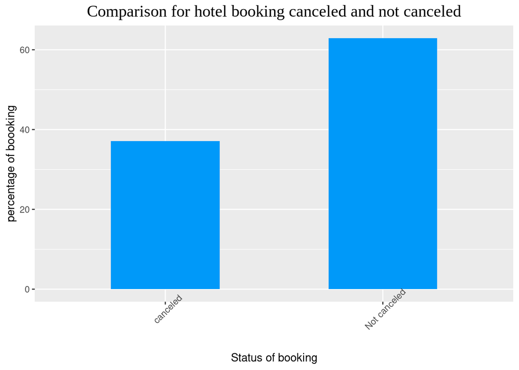

```r
ggplot(is_canceled_df, aes(x = is_canceled, y = percent_canceled)) +
  geom_col(
    stat="identity", width=0.5, fill = "#0099f9"
  ) +
  labs(
    title = "Comparison for hotel booking canceled and not canceled",
    x = "Status of booking",
    y = "percentage of boooking"
  )+
  theme(
    plot.title = element_text(hjust = 0.5, size=16, family="Times New Roman"),
    axis.text.x = element_text(angle = 45, hjust = 0.5)
  )
```

```r
# 2. What was the booking ratio between resort hotel and city hotel?
# ---
# Barplot of booking ratio between resort hotel and city hotel
hotel_type_df <- cleaned_hotels_df %>%
  group_by(hotel)%>%
  summarise(hotel_count = length(hotel))%>%
  mutate(percent_hotel = 100 * (hotel_count/sum(hotel_count)) )

hotel_type_df
```

| hotel | hotel_count | percent_hotel |
| --- | --- | --- |
| City Hotel | 79163 | 66.40634 |
| Resort Hotel | 40047 | 33.59366 |

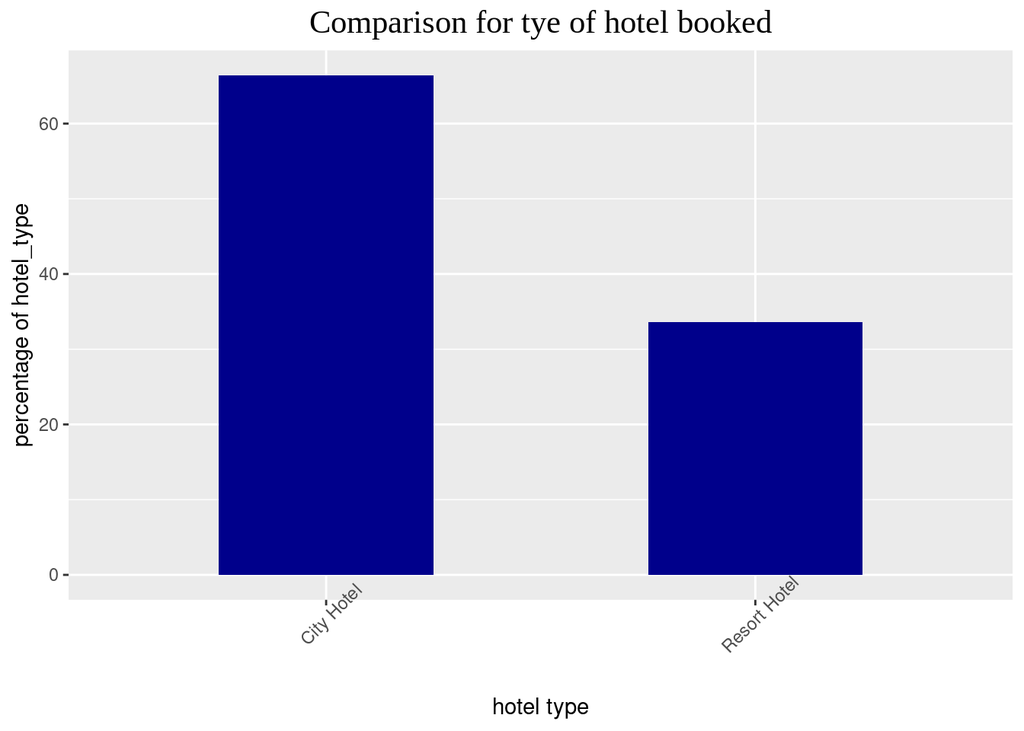

```r
ggplot(hotel_type_df, aes(x = hotel, y = percent_hotel)) +
  geom_col(
    stat="identity", width=0.5, fill = "darkblue"
  ) +
  labs(
    title = "Comparison for tye of hotel booked",
    x = "hotel type",
    y = "percentage of hotel_type"
  )+
  theme(
    plot.title = element_text(hjust = 0.5, size=16, family="Times New Roman"),
    axis.text.x = element_text(angle = 45, hjust = 0.5)
  )
```

```r
# 3. What was the percentage of booking for each year?
# ---
#
year_df <- cleaned_hotels_df %>%
  group_by(arrival_date_year)%>%
  summarise(year_count = length(arrival_date_year))%>%
  mutate(percent_year = 100 * (year_count/sum(year_count)) )

year_df
```

| arrival_date_year | year_count | percent_year |
| --- | --- | --- |
| 2015 | 21967 | 18.42715 |
| 2016 | 56623 | 47.49853 |
| 2017 | 40620 | 34.07432 |

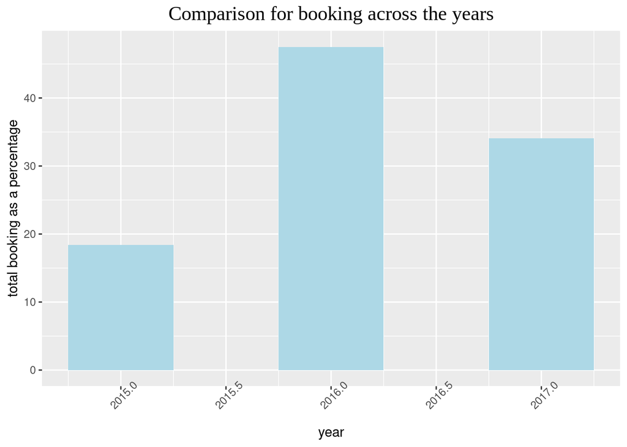

```r
ggplot(year_df, aes(x = arrival_date_year, y = percent_year)) +
  geom_col(
    stat="identity", width=0.5, fill = "lightblue"
  ) +
  labs(
    title = "Comparison for booking across the years",
    x = "year",
    y = "total booking as a percentage"
  )+
  theme(
    plot.title = element_text(hjust = 0.5, size=16, family="Times New Roman"),
    axis.text.x = element_text(angle = 45, hjust = 0.5)
  )
```

```r
# 4. Which were the most busiest months for hotels?
# ---
#
month_df <- cleaned_hotels_df %>%
  group_by(arrival_date_month)%>%
  summarise(guest_per_month = sum(guest))

month_df
```

| arrival_date_month | guest_per_month |
| --- | --- |
| April | 22000 |
| August | 30771 |
| December | 13196 |
| February | 15299 |
| January | 10524 |
| July | 27607 |
| June | 21481 |
| March | 18432 |
| May | 22456 |
| November | 11812 |

[output cut: 2 more lines]

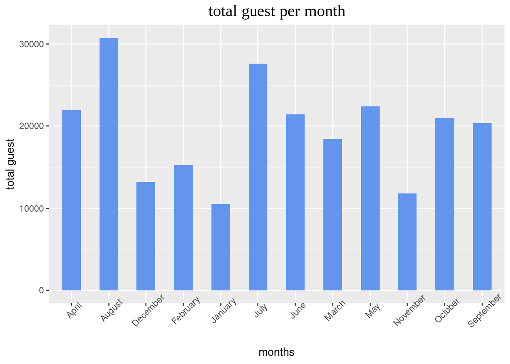

```r
ggplot(month_df, aes(x = arrival_date_month, y = guest_per_month)) +
  geom_col(
    stat="identity", width=0.5, fill = "cornflowerblue"
  ) +
  labs(
    title = "total guest per month",
    x = "months",
    y = "total guest"
  )+
  theme(
    plot.title = element_text(hjust = 0.5, size=16, family="Times New Roman"),
    axis.text.x = element_text(angle = 45, hjust = 0.5)
  )
```

```r
# 5. From which top 3 countries did most guests come from?
# ---
# YOUR GOES BELOW
#
countries_df <- cleaned_hotels_df %>%
  group_by(country)%>%
  summarise(total_guest = sum(guest))%>%
  top_n(3)
countries_df
```

| country | total_guest |
| --- | --- |
| FRA | 21579 |
| GBR | 24568 |
| PRT | 90036 |

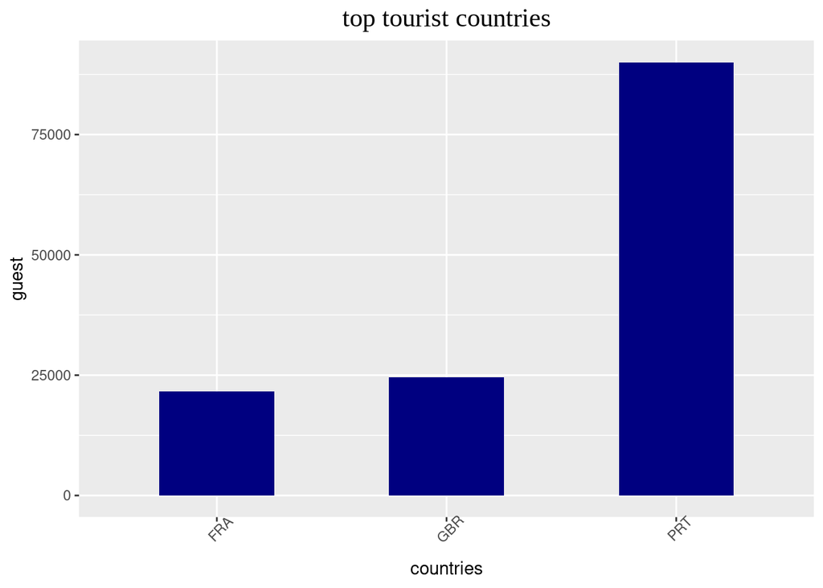

```r
ggplot(countries_df, aes(x = country, y = total_guest)) +
  geom_col(
    stat="identity", width=0.5, fill = "navyblue"
  ) +
  labs(
    title = "top tourist countries",
    x = "countries",
    y = "guest"
  )+
  theme(
    plot.title = element_text(hjust = 0.5, size=16, family="Times New Roman"),
    axis.text.x = element_text(angle = 45, hjust = 0.5)
  )
```

```r
# 6.a) How long do most people stay in hotels?
#   b) By city and resort? Separate the data by hotel
# ---
#
stay_period_df <- cleaned_hotels_df %>%
  group_by(hotel)%>%
  summarise(stays_period = mean(stays_period))

stay_period_df
```

| hotel | stays_period |
| --- | --- |
| City Hotel | 2.974938 |
| Resort Hotel | 4.318376 |

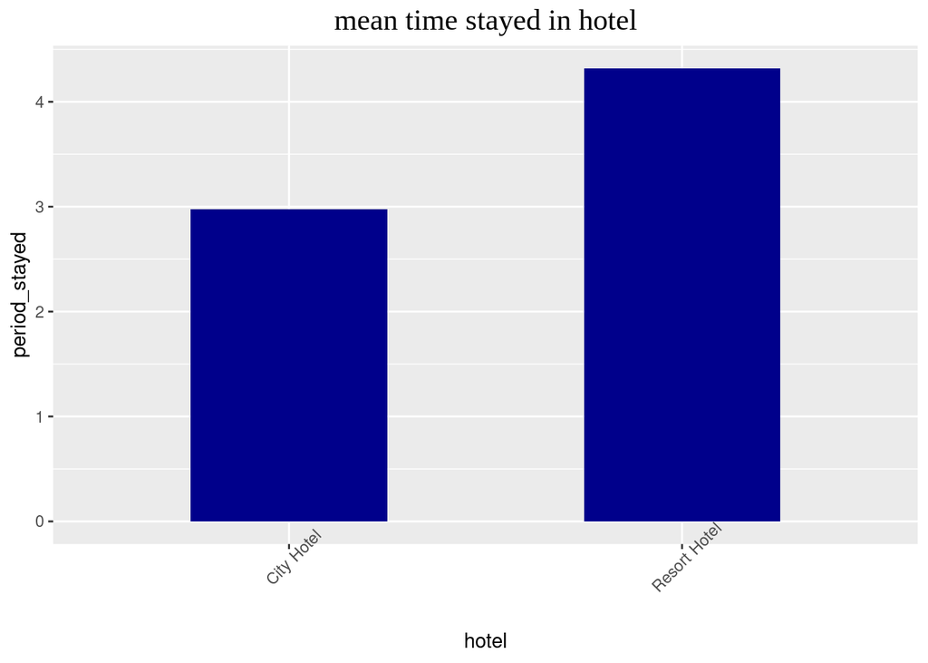

```r
ggplot(stay_period_df, aes(x = hotel, y = stays_period)) +
  geom_col(
    stat="identity", width=0.5, fill = "darkblue"
  ) +
  labs(
    title = "mean time stayed in hotel",
    x = "hotel",
    y = "period_stayed"
  )+
  theme(
    plot.title = element_text(hjust = 0.5, size=16, family="Times New Roman"),
    axis.text.x = element_text(angle = 45, hjust = 0.5)
  )
```

```r
# 7. Which was the most booked accommodation type (Single, Couple, Family)?
# ---
#
#NO variable with such information.
#assume single status = 1 adults, no children and no baby; couple= 2 adults no children and no baby, family rest
accommodation_df <- cleaned_hotels_df
accommodation_df <- accommodation_df %>%
  filter(adults==1 & children==0 & babies==0)%>%
  mutate(marital_status = "single")


filter(accommodation_df, (adults >1 & (children>0)))
```

| hotel | is_canceled | lead_time | arrival_date_year | arrival_date_month | arrival_date_week_number | arrival_date_day_of_month | stays_in_weekend_nights | stays_in_week_nights | adults | children | babies | meal | country | market_segment | distribution_channel | is_repeated_guest | previous_cancellations | previous_bookings_not_canceled | reserved_room_type | assigned_room_type | booking_changes | deposit_type | agent | days_in_waiting_list | customer_type | adr | required_car_parking_spaces | total_of_special_requests | reservation_status | … |
| --- | --- | --- | --- | --- | --- | --- | --- | --- | --- | --- | --- | --- | --- | --- | --- | --- | --- | --- | --- | --- | --- | --- | --- | --- | --- | --- | --- | --- | --- | --- |

```r
nrow(accommodation_df$marital_status[accommodation_df$marital_status=="single"])
```

[output not shown]

### 5.b) Recommendations

From the above analysis, below are our recommendations: 1. Countries to target for advertisement are PRT, GBR and France, in that order bacause most guest came from there 2. Offer good deals for the month of April to August because that when most people visit 3. Hotel needs to revisit the condition around 2016 because that was when most guest came in 4. City hotel was the more booked than resort hotel but guest stayed longer in resort hotel. Management needs to provide revenue data to help make decision

## 6. Challenging your Solution

In this step, we review our solution and implement approaches that could potentially provide a better outcome. In our case, we could propose the following question that wasn’t answered in our solution because it couldn’t have greatly contributed to our recommendation.

```r
# When should hotels provide special offers?
# ---
# YOUR GOES BELOW
#
#1. how many of our guest required parking

parking_df <- cleaned_hotels_df %>%
  group_by(required_car_parking_spaces)%>%
  summarise(parking_spaces = length(required_car_parking_spaces))


parking_df
```

| required_car_parking_spaces | parking_spaces |
| --- | --- |
| 0 | 111801 |
| 1 | 7376 |
| 2 | 28 |
| 3 | 3 |
| 8 | 2 |

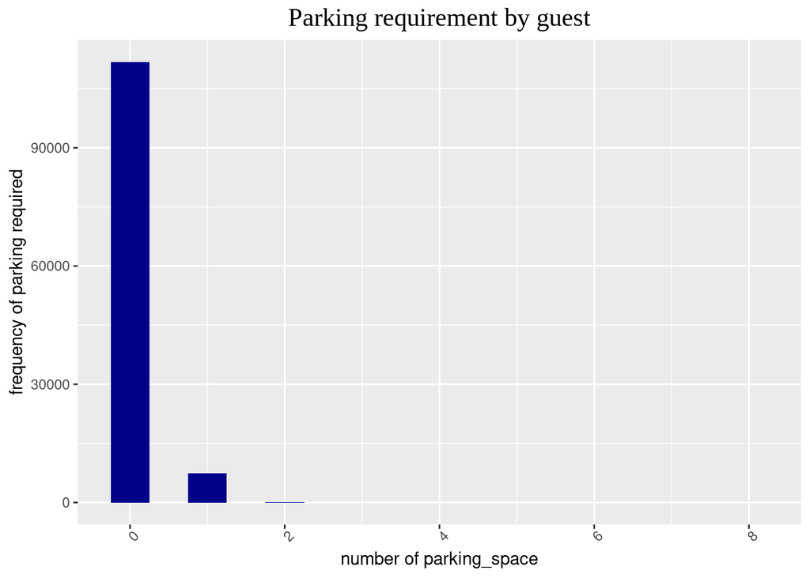

```r
ggplot(parking_df, aes(x = required_car_parking_spaces, y = parking_spaces)) +
  geom_col(
    stat="identity", width=0.5, fill = "darkblue"
  ) +
  labs(
    title = "Parking requirement by guest",
    x = "number of parking_space",
    y = "frequency of parking required"
  )+
  theme(
    plot.title = element_text(hjust = 0.5, size=16, family="Times New Roman"),
    axis.text.x = element_text(angle = 45, hjust = 0.5)
  )
```

Our observations: -April to August are when most guest visit, so hotel should provide special offers to other months other than April to August to attract off holiday guest most guest dont require parking

How does this observation tie to our solution? 1. hotel can save on investing on parking spaces

## 7. Follow up questions

During this step, you rethink and propose other ways that you can improve your solution.

a). Did we have the right data? 1. Yes, but more data can help make good decision like hotel revenue 2. There was no column with family status(single, couple, married) b). Do we need other data to answer our question? revenue data, family status c). Did we have the right question? Yes